# Econometric Time-Series Forecasting of Zinc Prices (1990-2025): ARIMA Modeling and Statistical Diagnostics

Tymoteusz Pawełczyk

March 11, 2026

## Executive Summary

This report presents a comprehensive time-series analysis and forecasting framework for zinc prices covering the period from January 1990 to March 2025. The objective of the study is to identify the statistical properties of the zinc price process and construct a reliable short-term forecasting model using classical econometric time-series methods.

The empirical procedure follows a structured workflow that includes decomposition of the time series, variance stabilization diagnostics, stationarity testing, identification of autoregressive structures, ARIMA model estimation, and out-of-sample forecasting evaluation. In addition, the forecasting performance of ARIMA models is compared with an extrapolative benchmark based on the Holt exponential smoothing method.

The results indicate that zinc prices exhibit strong cyclical fluctuations typical for commodity markets. After logarithmic transformation and differencing, the time series satisfies the stationarity conditions required for ARIMA modeling. Several ARIMA specifications are estimated and compared using statistical diagnostics, information criteria, and forecasting accuracy measures.

## 1. Data Description

The analyzed dataset consists of observations for the zinc price index expressed in U.S. dollars per metric ton. The data have a monthly frequency and are not seasonally adjusted. The dataset was obtained from the Federal Reserve Economic Data (FRED) database.

The sample contains 423 observations. The first observation corresponds to January 1990, while the last observation corresponds to March 2025. This long time span makes it possible to capture several commodity price cycles and structural changes in the zinc market.

Figure 1 presents the evolution of both the price level and the logarithm of price over time. The logarithmic transformation allows for easier interpretation of relative changes and stabilizes the variance of the series, which is particularly important in the context of econometric modeling.

The raw price series reveals substantial fluctuations over time, including periods of rapid growth and decline. Such behavior is typical for commodity markets and reflects the influence of global industrial demand, supply conditions, macroeconomic cycles, and speculative activity.

```r
raw_data <- readr::read_csv("zinc_prices.csv", show_col_types = FALSE)

zinc_df <- raw_data %>%
  dplyr::transmute(
    date = as.Date(paste0("01-", Date), format = "%d-%b-%y"),
    price = as.numeric(gsub(",", ".", gsub("\\s+", "", Price)))
  ) %>%
  dplyr::arrange(date) %>%
  dplyr::mutate(log_price = log(price))

if (anyNA(zinc_df$date) || anyNA(zinc_df$price)) {
  stop("Date or price parsing generated missing values.")
}
if (any(zinc_df$price <= 0)) {
  stop("Non-positive prices detected. Log transformation is invalid.")
}
if (dplyr::n_distinct(zinc_df$date) != nrow(zinc_df)) {
  stop("Duplicate monthly timestamps detected.")
}

start_year <- as.integer(format(min(zinc_df$date), "%Y"))
start_month <- as.integer(format(min(zinc_df$date), "%m"))

price_ts <- ts(zinc_df$price, start = c(start_year, start_month), frequency = 12)
log_price_ts <- ts(zinc_df$log_price, start = c(start_year, start_month), frequency = 12)
diff_log_price_ts <- diff(log_price_ts)
```

```r
qa_table <- tibble::tibble(
  metric = c(
    "Observations",
    "Start date",
    "End date",
    "Missing dates",
    "Missing prices",
    "Duplicate dates"
  ),
  value = c(
    nrow(zinc_df),
    as.character(min(zinc_df$date)),
    as.character(max(zinc_df$date)),
    sum(is.na(zinc_df$date)),
    sum(is.na(zinc_df$price)),
    nrow(zinc_df) - dplyr::n_distinct(zinc_df$date)
  )
)

knitr::kable(qa_table, caption = "Table QA. Input data quality checks")
```

Table QA. Input data quality checks

| metric | value |
| --- | --- |
| Observations | 423 |
| Start date | 1990-01-01 |
| End date | 2025-03-01 |
| Missing dates | 0 |
| Missing prices | 0 |
| Duplicate dates | 0 |

*Source: Author’s own elaboration*

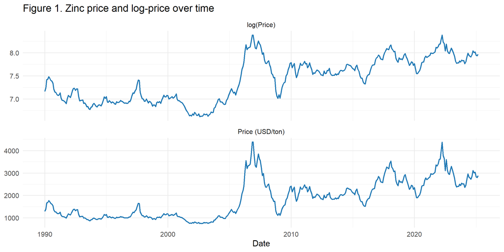

```r
plot_df <- zinc_df %>%
  dplyr::select(date, price, log_price) %>%
  tidyr::pivot_longer(cols = c(price, log_price), names_to = "series", values_to = "value") %>%
  dplyr::mutate(
    series = dplyr::recode(
      series,
      price = "Price (USD/ton)",
      log_price = "log(Price)"
    )
  )

ggplot2::ggplot(plot_df, ggplot2::aes(x = date, y = value)) +
  ggplot2::geom_line(color = "#1f78b4", linewidth = 0.8) +
  ggplot2::facet_wrap(~series, scales = "free_y", ncol = 1) +
  ggplot2::labs(
    title = "Figure 1. Zinc price and log-price over time",
    x = "Date",
    y = NULL
  ) +
  ggplot2::theme_minimal(base_size = 12)
```

*Source: Author’s own elaboration*

## 2. Time-Series Decomposition

The decomposition confirms that the analyzed series does not contain a significant seasonal component. The seasonally adjusted series almost completely overlaps with the original series, indicating that seasonal fluctuations do not play a major role in the dynamics of zinc prices.

Instead, the data exhibit strong cyclical behavior, which is typical for commodity prices. Particularly noticeable are significant price increases during the periods 2006-2008 and 2020-2022, followed by substantial price declines.

These fluctuations can be interpreted as manifestations of commodity market cycles driven by global economic conditions. The long-term trend between 1990 and 2004 remained relatively stable. However, between 2004 and 2025 the series exhibits an overall upward trend accompanied by significant cyclical volatility.

An additional feature of the series is the increasing amplitude of price fluctuations over time. This suggests that the underlying trend follows a multiplicative structure rather than an additive one. Furthermore, the irregular changes in the direction of the trend indicate that the process may be stochastic in nature rather than deterministic.

```r
stl_fit <- stats::stl(log_price_ts, s.window = "periodic", robust = TRUE)

seasonally_adjusted_log <- forecast::seasadj(stl_fit)
seasonally_adjusted_price <- exp(as.numeric(seasonally_adjusted_log))
trend_cycle_price <- exp(as.numeric(stl_fit$time.series[, "trend"]))

decomp_df <- tibble::tibble(
  date = zinc_df$date,
  original_price = zinc_df$price,
  trend_cycle_price = trend_cycle_price,
  sa_price = seasonally_adjusted_price
)

seasonality_strength <- max(
  0,
  1 - stats::var(stl_fit$time.series[, "remainder"], na.rm = TRUE) /
    stats::var(stl_fit$time.series[, "remainder"] + stl_fit$time.series[, "seasonal"], na.rm = TRUE)
)

decomp_summary <- tibble::tibble(
  metric = c(
    "Seasonality strength (0 to 1)",
    "Correlation original vs seasonally adjusted"
  ),
  value = c(
    round(seasonality_strength, 4),
    round(stats::cor(decomp_df$original_price, decomp_df$sa_price), 4)
  )
)

knitr::kable(decomp_summary, caption = "Table 2. Decomposition diagnostics")
```

Table 2. Decomposition diagnostics

| metric | value |
| --- | --- |
| Seasonality strength (0 to 1) | 0.0000 |
| Correlation original vs seasonally adjusted | 0.9994 |

*Source: Author’s own elaboration*

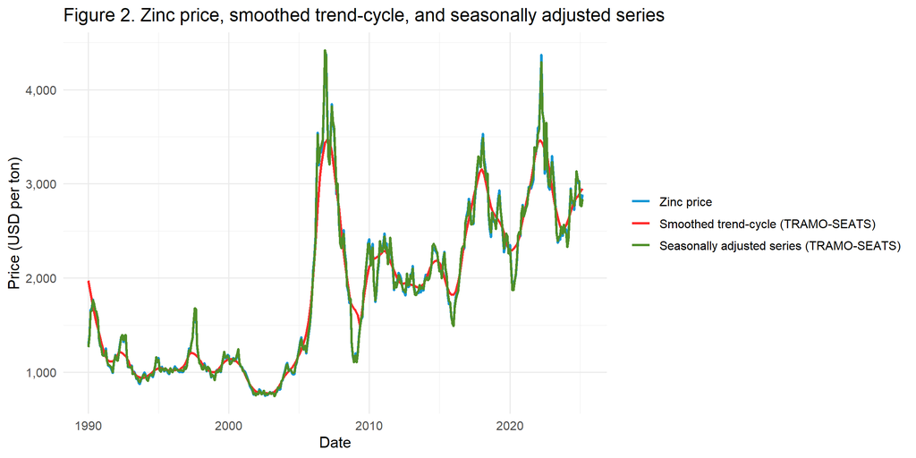

```r
figure2_df <- decomp_df %>%
  dplyr::transmute(
    date,
    `Zinc price` = original_price,
    `Smoothed trend-cycle (TRAMO-SEATS)` = trend_cycle_price,
    `Seasonally adjusted series (TRAMO-SEATS)` = sa_price
  ) %>%
  tidyr::pivot_longer(cols = -date, names_to = "series", values_to = "value") %>%
  dplyr::mutate(
    series = factor(
      series,
      levels = c(
        "Zinc price",
        "Smoothed trend-cycle (TRAMO-SEATS)",
        "Seasonally adjusted series (TRAMO-SEATS)"
      )
    )
  )

ggplot2::ggplot(figure2_df, ggplot2::aes(x = date, y = value, color = series)) +
  ggplot2::geom_line(linewidth = 0.9) +
  ggplot2::scale_color_manual(
    values = c(
      "Zinc price" = "#1496d4",
      "Smoothed trend-cycle (TRAMO-SEATS)" = "#ff2b2b",
      "Seasonally adjusted series (TRAMO-SEATS)" = "#4f8f29"
    )
  ) +
  ggplot2::scale_y_continuous(labels = scales::comma) +
  ggplot2::labs(
    title = "Figure 2. Zinc price, smoothed trend-cycle, and seasonally adjusted series",
    x = "Date",
    y = "Price (USD per ton)",
    color = NULL
  ) +
  ggplot2::theme_minimal(base_size = 12)
```

*Source: Author’s own elaboration*

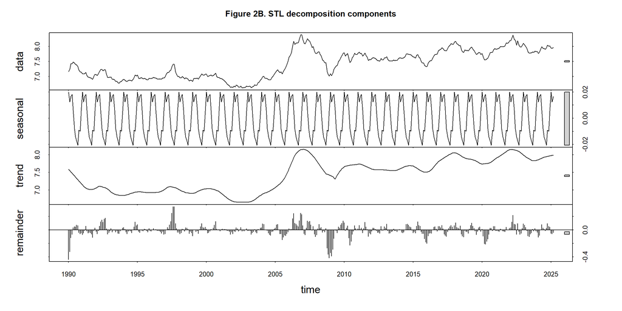

```r
plot(stl_fit, main = "Figure 2B. STL decomposition components")
```

*Source: Author’s own elaboration*

## 3. ARIMA Model

### 3.1 Stationarity

To determine whether the analyzed time series requires logarithmic transformation, the Box-Cox test was conducted. The test evaluates the log-likelihood function for different values of the transformation parameter lambda.

The results indicate that the maximum of the log-likelihood function occurs within the 95% confidence interval for values of lambda close to zero. Consequently, the logarithmic transformation (lambda = 0) can be considered statistically justified.

Next, the degree of integration of the log(price) series was examined using the Dickey-Fuller (DF) test and Augmented Dickey-Fuller (ADF) tests with one and two lagged differences. Additionally, the Breusch-Godfrey test was performed for lags from 1 to 6 in order to verify the presence of residual autocorrelation.

The results indicate that the DF model suffers from strong residual autocorrelation, as the p-values for all tested lags are close to zero. Therefore, the null hypothesis of no residual autocorrelation must be rejected.

For the ADF model with one lag extension, the situation improves significantly. For lags 1 and 2 the p-values exceed the significance level of 0.05, meaning that there are no grounds to reject the null hypothesis of no residual autocorrelation. However, for higher lags residual autocorrelation remains present.

Only the ADF model with two lag extensions fully satisfies the assumption of independent residuals. In this specification, the p-values exceed 0.05 for all tested lags, indicating that the null hypothesis of no residual autocorrelation cannot be rejected.

The test statistic for the ADF test with two lag extensions equals -3.4578. This value is lower than the critical values for significance levels of 5% and 10%, but higher than the critical value for 1%. Therefore, the null hypothesis of a unit root can be rejected at the 5% significance level.

As a result, the logarithm of zinc prices can be treated as a stationary process suitable for further modeling.

After differencing the logarithmic series, the transformed series shows fluctuations around a stable mean without visible long-term trends. Nevertheless, residual autocorrelation remains present in the DF specification. For lags 3-5 the p-values fall below 0.05, indicating that the null hypothesis of no residual autocorrelation should be rejected.

In contrast, the ADF test with one lag extension shows no evidence of residual autocorrelation for any tested lag, since all p-values exceed the 0.05 threshold.

To further verify the statistical properties of the differenced series, the Portmanteau (Ljung-Box) test was conducted using 20 lags. The obtained p-value is below the 0.05 significance level, indicating that the null hypothesis of no autocorrelation must be rejected.

This result implies that the differenced log-price series is not white noise, which confirms that additional autoregressive and moving-average components may be used for modeling.

```r
lambda_guerrero <- forecast::BoxCox.lambda(price_ts, method = "guerrero")

boxcox_table <- tibble::tibble(
  diagnostic = "Guerrero Box-Cox lambda",
  value = round(lambda_guerrero, 3),
  interpretation = ifelse(
    abs(lambda_guerrero) < 0.2,
    "Near zero: log transform is justified",
    "Not near zero: alternative transform should be evaluated"
  )
)

knitr::kable(boxcox_table, caption = "Table BC. Variance stabilization diagnostic")
```

Table BC. Variance stabilization diagnostic

| diagnostic | value | interpretation |
| --- | --- | --- |
| Guerrero Box-Cox lambda | -0.121 | Near zero: log transform is justified |

*Source: Author’s own elaboration*

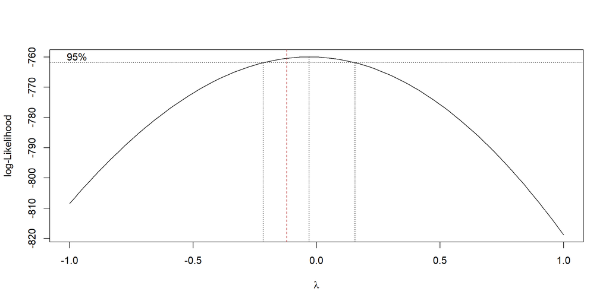

```r
price_clean <- stats::na.omit(zinc_df$price)
time_index <- seq_along(price_clean)
boxcox_model <- stats::lm(price_clean ~ time_index)

MASS::boxcox(
  boxcox_model,
  lambda = seq(-1, 1, 0.1),
  main = "Figure 3. Box-Cox test"
)
graphics::abline(v = lambda_guerrero, lty = 2, col = "firebrick")
```

*Source: Author’s own elaboration*

```r
bg_df_level <- run_bg_tests(log_price_ts, lags_adf = 0, max_bg_lag = 6)
bg_adf1_level <- run_bg_tests(log_price_ts, lags_adf = 1, max_bg_lag = 6)
bg_adf2_level <- run_bg_tests(log_price_ts, lags_adf = 2, max_bg_lag = 6)

bg_level_table <- tibble::tibble(
  Lag = bg_df_level$lag,
  `DF test - B-G statistic` = round(bg_df_level$statistic, 3),
  `DF test - p-value` = signif(bg_df_level$p_value, 4),
  `ADF test with 1 lag extension - B-G statistic` = round(bg_adf1_level$statistic, 3),
  `ADF test with 1 lag extension - p-value` = signif(bg_adf1_level$p_value, 4),
  `ADF test with 2 lag extensions - B-G statistic` = round(bg_adf2_level$statistic, 3),
  `ADF test with 2 lag extensions - p-value` = signif(bg_adf2_level$p_value, 4)
)

knitr::kable(
  bg_level_table,
  caption = "Table 1. Breusch-Godfrey residual diagnostics for DF and ADF models",
  digits = 4
)
```

Table 1. Breusch-Godfrey residual diagnostics for DF and ADF models

| Lag | DF test - B-G statistic | DF test - p-value | ADF test with 1 lag extension - B-G statistic | ADF test with 1 lag extension - p-value | ADF test with 2 lag extensions - B-G statistic | ADF test with 2 lag extensions - p-value |
| --- | --- | --- | --- | --- | --- | --- |
| 1 | 31.917 | 0 | 1.389 | 0.2386 | 0.464 | 0.4958 |
| 2 | 32.330 | 0 | 2.484 | 0.2888 | 0.783 | 0.6759 |
| 3 | 32.373 | 0 | 10.510 | 0.0147 | 4.091 | 0.2519 |
| 4 | 37.947 | 0 | 12.167 | 0.0162 | 7.018 | 0.1350 |
| 5 | 37.966 | 0 | 12.587 | 0.0276 | 7.490 | 0.1867 |
| 6 | 38.007 | 0 | 12.626 | 0.0494 | 7.490 | 0.2779 |

*Source: Author’s own elaboration*

```r
adf_ur_level_l2 <- urca::ur.df(log_price_ts, type = "trend", lags = 2)

adf_level_critical_table <- tibble::tibble(
  `Test statistic value` = round(adf_ur_level_l2@teststat[1], 4),
  `1%` = round(adf_ur_level_l2@cval[1, "1pct"], 2),
  `5%` = round(adf_ur_level_l2@cval[1, "5pct"], 2),
  `10%` = round(adf_ur_level_l2@cval[1, "10pct"], 2)
)

knitr::kable(
  adf_level_critical_table,
  caption = "Table 2. ADF test with 2 lag extensions for log(price)",
  digits = 4
)
```

Table 2. ADF test with 2 lag extensions for log(price)

| Test statistic value | 1% | 5% | 10% |
| --- | --- | --- | --- |
| -3.4578 | -3.98 | -3.42 | -3.13 |

*Source: Author’s own elaboration*

```r
adf_level_tseries <- tseries::adf.test(log_price_ts, k = 2)
adf_diff_tseries <- tseries::adf.test(diff_log_price_ts, k = 2)

adf_tseries_table <- tibble::tibble(
  series = c("log(price)", "difference of log(price)"),
  statistic = c(unname(adf_level_tseries$statistic), unname(adf_diff_tseries$statistic)),
  p_value = c(adf_level_tseries$p.value, adf_diff_tseries$p.value)
)

knitr::kable(
  adf_tseries_table,
  caption = "Table ADF (tseries) for level and differenced series",
  digits = 4
)
```

Table ADF (tseries) for level and differenced series

| series | statistic | p_value |
| --- | --- | --- |
| log(price) | -3.4578 | 0.0467 |
| difference of log(price) | -10.6289 | 0.0100 |

*Source: Author’s own elaboration*

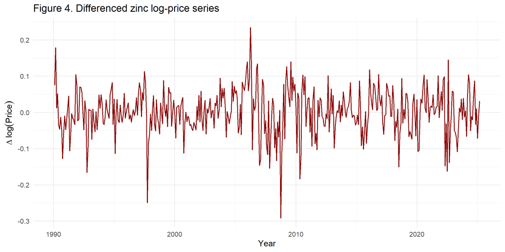

```r
diff_plot_df <- tibble::tibble(
  date = zinc_df$date[-1],
  diff_log = as.numeric(diff_log_price_ts)
)

ggplot2::ggplot(diff_plot_df, ggplot2::aes(x = date, y = diff_log)) +
  ggplot2::geom_line(color = "darkred", linewidth = 0.7) +
  ggplot2::labs(
    title = "Figure 4. Differenced zinc log-price series",
    x = "Year",
    y = expression(Delta ~ log(Price))
  ) +
  ggplot2::theme_minimal(base_size = 12)
```

*Source: Author’s own elaboration*

```r
bg_df_diff <- run_bg_tests(diff_log_price_ts, lags_adf = 0, max_bg_lag = 6)
bg_adf1_diff <- run_bg_tests(diff_log_price_ts, lags_adf = 1, max_bg_lag = 6)
bg_adf2_diff <- run_bg_tests(diff_log_price_ts, lags_adf = 2, max_bg_lag = 6)

bg_diff_table <- tibble::tibble(
  Lag = bg_df_diff$lag,
  `DF test - B-G statistic` = round(bg_df_diff$statistic, 3),
  `DF test - p-value` = signif(bg_df_diff$p_value, 4),
  `ADF test with 1 lag extension - B-G statistic` = round(bg_adf1_diff$statistic, 3),
  `ADF test with 1 lag extension - p-value` = signif(bg_adf1_diff$p_value, 4),
  `ADF test with 2 lag extensions - B-G statistic` = round(bg_adf2_diff$statistic, 3),
  `ADF test with 2 lag extensions - p-value` = signif(bg_adf2_diff$p_value, 4)
)

knitr::kable(
  bg_diff_table,
  caption = "Table 3. Breusch-Godfrey residual diagnostics for DF and ADF models",
  digits = 4
)
```

Table 3. Breusch-Godfrey residual diagnostics for DF and ADF models

| Lag | DF test - B-G statistic | DF test - p-value | ADF test with 1 lag extension - B-G statistic | ADF test with 1 lag extension - p-value | ADF test with 2 lag extensions - B-G statistic | ADF test with 2 lag extensions - p-value |
| --- | --- | --- | --- | --- | --- | --- |
| 1 | 1.110 | 0.2921 | 0.473 | 0.4916 | 3.478 | 0.0622 |
| 2 | 2.178 | 0.3366 | 0.570 | 0.7521 | 4.072 | 0.1305 |
| 3 | 10.047 | 0.0182 | 3.611 | 0.3067 | 4.751 | 0.1909 |
| 4 | 11.620 | 0.0204 | 6.434 | 0.1690 | 6.411 | 0.1705 |
| 5 | 11.836 | 0.0371 | 6.685 | 0.2452 | 7.410 | 0.1919 |
| 6 | 11.990 | 0.0622 | 6.727 | 0.3468 | 7.460 | 0.2804 |

*Source: Author’s own elaboration*

```r
adf_ur_diff_l2 <- urca::ur.df(diff_log_price_ts, type = "trend", lags = 2)

adf_diff_critical_table <- tibble::tibble(
  `Test statistic value` = round(adf_ur_diff_l2@teststat[1], 4),
  `1%` = round(adf_ur_diff_l2@cval[1, "1pct"], 2),
  `5%` = round(adf_ur_diff_l2@cval[1, "5pct"], 2),
  `10%` = round(adf_ur_diff_l2@cval[1, "10pct"], 2)
)

knitr::kable(
  adf_diff_critical_table,
  caption = "Table 4. ADF test with 2 lag extensions for differenced log(price)",
  digits = 4
)
```

Table 4. ADF test with 2 lag extensions for differenced log(price)

| Test statistic value | 1% | 5% | 10% |
| --- | --- | --- | --- |
| -10.6289 | -3.98 | -3.42 | -3.13 |

*Source: Author’s own elaboration*

```r
lb_diff <- stats::Box.test(diff_log_price_ts, lag = 20, type = "Ljung-Box")

cat("### Figure 5. Portmanteau (Ljung-Box) test\n\n")
```